# Statistics Project

### By : Abhishek Sarakanam

## Importing necessary libraries

```python
import numpy as np
import pandas as pd
import seaborn as sns
import matplotlib.pyplot as plt
from scipy import stats
```

## Read data as dataframe

```python
insurance = pd.read_csv("C:\\Users\\sivaabhishek\\Downloads\\insurance.csv")
```

## Exploratory data analysis

### 1. Shape of data

```python
insurance.shape
```

```
(1338, 7)
```

### 2. Data type of each attribute

```python
insurance.dtypes
```

```
age           int64
sex          object
bmi         float64
children      int64
smoker       object
region       object
charges     float64
dtype: object
```

### 3. Checking missing values

```python
insurance[insurance.isna().any(axis=1)]
```

|  | age | sex | bmi | children | smoker | region | charges |
| --- | --- | --- | --- | --- | --- | --- | --- |

### 4. 5 point summary of numerical columns

```python
insurance.describe(include = [np.number])
```

|  | age | bmi | children | charges |
| --- | --- | --- | --- | --- |
| count | 1338.000000 | 1338.000000 | 1338.000000 | 1338.000000 |
| mean | 39.207025 | 30.663397 | 1.094918 | 13270.422265 |
| std | 14.049960 | 6.098187 | 1.205493 | 12110.011237 |
| min | 18.000000 | 15.960000 | 0.000000 | 1121.873900 |
| 25% | 27.000000 | 26.296250 | 0.000000 | 4740.287150 |
| 50% | 39.000000 | 30.400000 | 1.000000 | 9382.033000 |
| 75% | 51.000000 | 34.693750 | 2.000000 | 16639.912515 |
| max | 64.000000 | 53.130000 | 5.000000 | 63770.428010 |

### 5. Distribution of bmi, age, charges

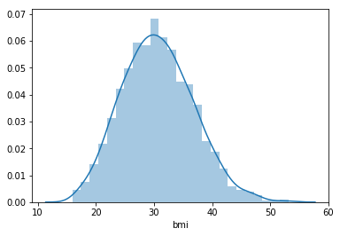

```python
sns.distplot(insurance.bmi);
```

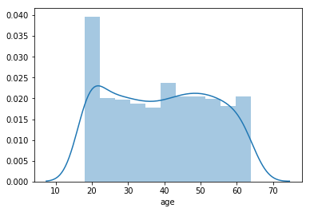

```python
sns.distplot(insurance.age);
```

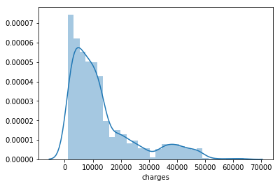

```python
sns.distplot(insurance.charges);
```

### 6. Measure of skewness of ‘bmi’, ‘age’ and ‘charges’

```python
insurance['bmi'].skew()
```

```
0.2840471105987448
```

```python
insurance.age.skew()
```

```
0.05567251565299186
```

```python
insurance.charges.skew()
```

```
1.5158796580240388
```

### 7. Checking the presence of outliers in ‘bmi’, ‘age’ and ‘charges columns

#### From pairplots we can see some points well far away from the other points which indicate outliers

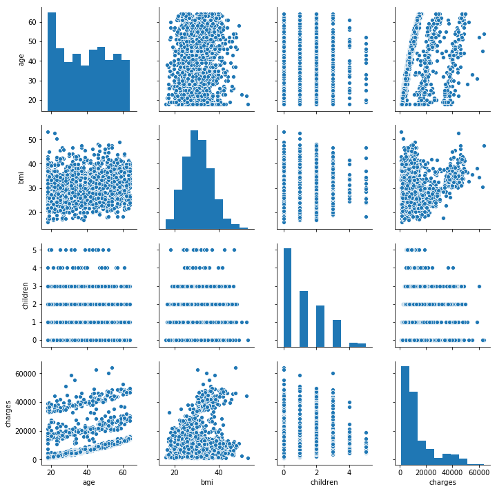

```python
sns.pairplot(insurance)
```

### OR

#### We can normalize our distribution using Z scores and then check for all points greater than 3 or less than -3

#### which means greater than 3 standard deviations and those points are classified as outliers.

```python
from scipy.stats import zscore
numeric_columns = insurance.select_dtypes(include=[np.number]).columns
ins_z_score = insurance[numeric_columns].apply(zscore).drop('children',axis=1)
```

#### Finding value of outliers for each attribute.

```python
ins_z_score[((ins_z_score.age<-3) | (ins_z_score.age>3))]
```

|  | age | bmi | charges |
| --- | --- | --- | --- |

```python
ins_z_score[((ins_z_score.bmi<-3) | (ins_z_score.bmi>3))].join(insurance, how='left',lsuffix="z")['bmi']
```

```
116     49.06
847     50.38
1047    52.58
1317    53.13
Name: bmi, dtype: float64
```

```python
ins_z_score[((ins_z_score.charges<-3) | (ins_z_score.charges>3))].join(insurance, how='left',lsuffix="z")['charges']
```

```
34      51194.55914
543     63770.42801
577     58571.07448
819     55135.40209
1146    52590.82939
1230    60021.39897
1300    62592.87309
Name: charges, dtype: float64
```

### 8. Distribution of categorical attributes

```python
insurance_categorical = insurance[['sex','smoker','region','children']]
```

#### Getting counts of each variable

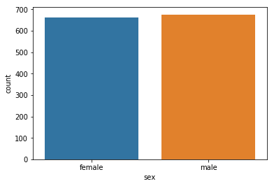

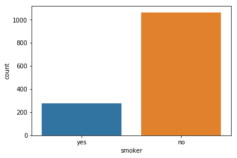

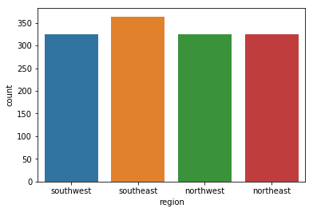

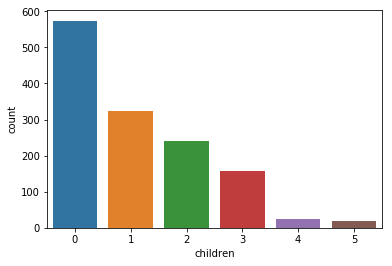

```python
sns.countplot(x='sex',data=insurance)
plt.show();
sns.countplot(x='smoker',data=insurance)
plt.show();
sns.countplot(x='region',data=insurance)
plt.show();
sns.countplot(x='children',data=insurance)
plt.show();
```

#### Finding distribution of smokers across sex

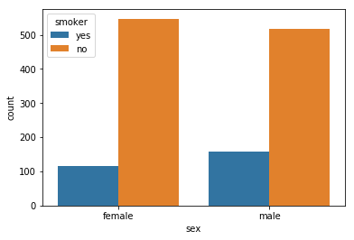

```python
sns.countplot(x='sex',data=insurance,hue='smoker');
```

#### Finding distribution of sex across region

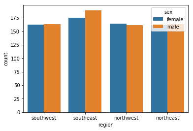

```python
sns.countplot(x='region',data=insurance,hue='sex');
```

#### Finding distribution of smokers accross region accross sex

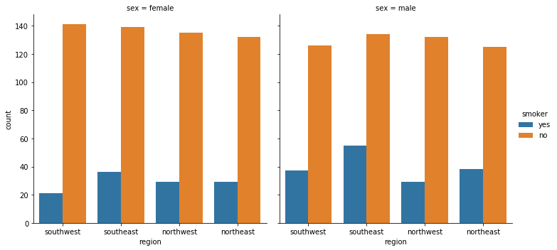

```python
sns.catplot(x='region',data=insurance,hue='smoker', col="sex", kind="count");
```

#### Finding distribution of number of children accross regions

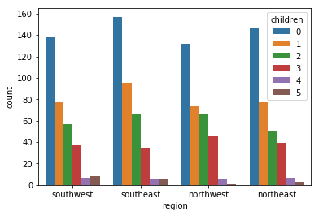

```python
sns.countplot(x='region',data=insurance,hue='children');
```

#### Finding distribution of smoking parents with respect to the number of children they have.

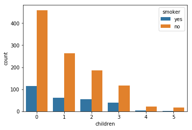

```python
sns.countplot(x='children',data=insurance,hue='smoker');
```

### 9. Pairplot of all columns of dataframe

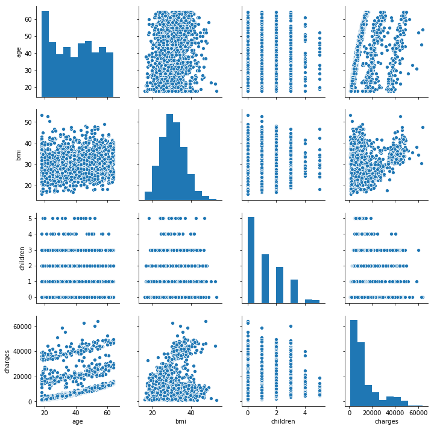

```python
sns.pairplot(data=insurance)
```

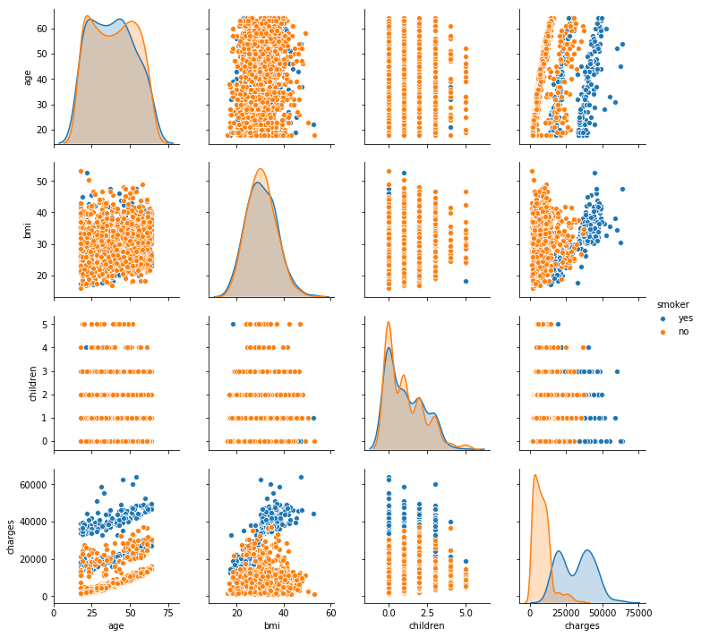

```python
sns.pairplot(data=insurance, hue="smoker");
```

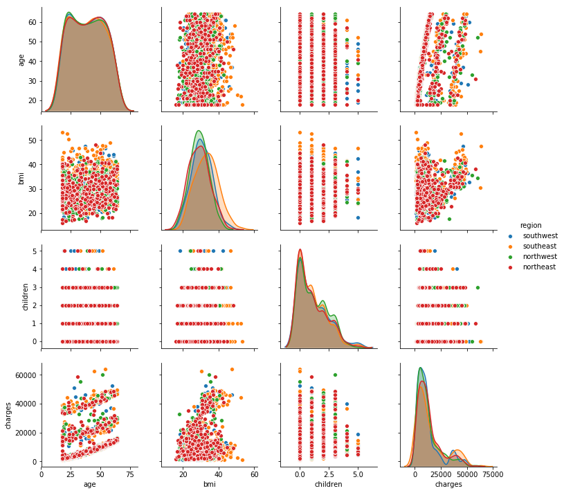

```python
sns.pairplot(data=insurance, hue="region");
```

### 4.a Smoker vs Charges

#### H0---> Smoker is independent of charges

```python
a = insurance[insurance.smoker=='yes'].charges
```

```python
b = insurance[insurance.smoker=='no'].charges
```

```python
t, p = stats.ttest_ind(a,b)
```

```python
print("%.300f" % p)
```

```
0.000000000000000000000000000000000000000000000000000000000000…
```

```python
if p<0.05:
    print("Rejecting H0")
else:
    print("Accepting H0")
```

```
Rejecting H0
```

As p value is very low p<<<<0.05, this tells us that the sample lies in the 5% region where population shows dependence between smoker and charges and as value is very low almost appproaching to 0, there is a very huge dependency between the both variables.

Thus, from t-test we get that charges of people who smoke differ significantly from the people who don't!!!

### 4.b bmi vs sex

#### H0---> bmi is independent of sex

```python
m = insurance[insurance.sex=='male'].bmi
```

```python
n = insurance[insurance.sex=='female'].bmi
```

```python
tb, pb = stats.ttest_ind(m,n)
```

```python
pb
```

```
0.08997637178984932
```

```python
if pb<0.05:
    print("Rejecting H0")
else:
    print("Accepting H0")
```

```
Accepting H0
```

As p value is 0.08 and lies in 95% we accept the H0. This tells that bmi of males does not differ significantly from that of females or bmi and sex are not dependent.

### 4.c Smoker vs Gender

#### H0---> Proportion of smokers is not significantly different in different genders

```
   ### --------> proportion of male smokers = proportion of female smokers
```

```python
Sm = insurance[(insurance['sex']=='male') & (insurance['smoker']=='yes')].smoker.count()
Tm = insurance[insurance['sex']=='male'].smoker.count()
Pm = Sm/Tm
Pm
```

```
0.23520710059171598
```

```python
Sf =  insurance[(insurance['sex']=='female') & (insurance['smoker']=='yes')].smoker.count()
Tf = insurance[insurance['sex']=='female'].smoker.count()
Pf = Sf/Tf
Pf
```

```
0.17371601208459214
```

```python
St = insurance[insurance['smoker']=='yes'].smoker.count()
Tt = insurance.smoker.count()
Pt = St/Tt
Pt
```

```
0.20478325859491778
```

```python
z = (Pm-Pf)/np.sqrt(Pt*(1-Pt)*((1/Tm)+(1/Tf)))
z
```

```
2.7867402154855503
```

```python
p_value = 2*stats.norm.sf(abs(z))
```

```python
if p_value<0.05:
    print("Rejecting H0")
else:
    print("Accepting H0")
```

```
Rejecting H0
```

Pm is the proportion of male smokers and Pf is the proportion of female smokers and Pt is the proportion of total smokers. Finding the Z value and its p_value of these proportions we find that p_value lies in 5% region. Hence we reject our null hyothesis.

Thus we say Proportions of smokers is significantly different in different genders.

### 4.d Bmi across women with no children, one child and two children

```python
insurance.head()
```

|  | age | sex | bmi | children | smoker | region | charges |
| --- | --- | --- | --- | --- | --- | --- | --- |
| 0 | 19 | female | 27.900 | 0 | yes | southwest | 16884.92400 |
| 1 | 18 | male | 33.770 | 1 | no | southeast | 1725.55230 |
| 2 | 28 | male | 33.000 | 3 | no | southeast | 4449.46200 |
| 3 | 33 | male | 22.705 | 0 | no | northwest | 21984.47061 |
| 4 | 32 | male | 28.880 | 0 | no | northwest | 3866.85520 |

```python
zero_c = insurance[(insurance.sex=='female')&(insurance.children==0)].bmi
```

```python
one_c = insurance[(insurance.sex=='female')&(insurance.children==1)].bmi
```

```python
two_c = insurance[(insurance.sex=='female')&(insurance.children==2)].bmi
```

#### Checking conditions if we can use anova:

1)Homogenity of variances: H0: samples from populations have equal variances

```python
stats.levene(zero_c,one_c,two_c)
```

```
LeveneResult(statistic=0.9433311607108589, pvalue=0.3899432394522804)
```

As the p-value is in 95%, we fail to reject null hypothesis. So, variances are homogenous accross the groups.

2) Normal distribution of residuals

H0: data is drawn from normal distribution

```python
stats.shapiro(zero_c)
```

```
(0.9896312355995178, 0.03757598251104355)
```

```python
stats.shapiro(one_c)
```

```
(0.9921025037765503, 0.5361911654472351)
```

```python
stats.shapiro(two_c)
```

```
(0.9860439300537109, 0.2596229910850525)
```

As zero_c group p_value is less than 0.05, this group doesnt come from a normal distribution. So, we try to normalize all the groups by square rooting them and rerunning levene and shapiro tests.

```python
z_c = np.sqrt(zero_c)
```

```python
o_c = np.sqrt(one_c)
```

```python
t_c = np.sqrt(two_c)
```

```python
stats.levene(z_c,o_c,t_c)
```

```
LeveneResult(statistic=0.916022362199881, pvalue=0.4007028357215552)
```

```python
stats.shapiro(z_c)
```

```
(0.9941864013671875, 0.33584892749786377)
```

```python
stats.shapiro(o_c)
```

```
(0.9968702793121338, 0.9859161376953125)
```

```python
stats.shapiro(t_c)
```

```
(0.9863975048065186, 0.27858781814575195)
```

```python
stats.f_oneway(z_c,o_c,t_c)
```

```
F_onewayResult(statistic=0.25358141447915666, pvalue=0.776105148637485)
```